# Exploratory Data Analysis of Red Wine & Diamond Datasets

$Author$: Michael Simons

$Class$: CSE 474 - Machine Learning

$Date$: 06/10/23

## Data Analysis - Red Wine Data

This section will analyze the red wine dataset which is in the form of a csv file titled `winequality-red.csv`, containing entries for attributes related to a specific red wine. To begin, the `Pandas` library will be utilized to extract the data and understand its formatting.

```python
import pandas as pd
wine_data = pd.read_csv('datasets/winequality-red.csv') #Extract data
wine_data.dtypes # Check expected datatypes of every feature
```

```
fixed acidity           float64
volatile acidity        float64
citric acid             float64
residual sugar          float64
chlorides               float64
free sulfur dioxide     float64
total sulfur dioxide    float64
density                 float64
pH                      float64
sulphates               float64
alcohol                 float64
quality                   int64
dtype: object
```

```python
wine_data.head(5) #Display first entries of the dataset to observe formatting
```

|  | fixed acidity | volatile acidity | citric acid | residual sugar | chlorides | free sulfur dioxide | total sulfur dioxide | density | pH | sulphates | alcohol | quality |
| --- | --- | --- | --- | --- | --- | --- | --- | --- | --- | --- | --- | --- |
| 0 | 7.4 | 0.70 | 0.00 | 1.9 | 0.076 | 11.0 | 34.0 | 0.9978 | 3.51 | 0.56 | 9.4 | 5 |
| 1 | 7.8 | 0.88 | 0.00 | 2.6 | 0.098 | 25.0 | 67.0 | 0.9968 | 3.20 | 0.68 | 9.8 | 5 |
| 2 | 7.8 | 0.76 | 0.04 | 2.3 | 0.092 | 15.0 | 54.0 | 0.9970 | 3.26 | 0.65 | 9.8 | 5 |
| 3 | 11.2 | 0.28 | 0.56 | 1.9 | 0.075 | 17.0 | 60.0 | 0.9980 | 3.16 | 0.58 | 9.8 | 6 |
| 4 | 7.4 | 0.70 | 0.00 | 1.9 | 0.076 | 11.0 | 34.0 | 0.9978 | 3.51 | 0.56 | 9.4 | 5 |

Observably, the order of the entries is unsorted. Each entry represents a distinct wine sample and the data consists of numerical values of type float for properties such as fixed acidity, volatile acidity, citric acid, residual sugar, chlorides, free sulfur dioxide, total sulfur dioxide, density, pH, sulphates, alcohol, and values of type int for a quality rating.

To verify that there are no missing values, we will calculate the sum of missing entries and adjust the data if necessary.

```python
wine_data.isnull().sum()
```

```
fixed acidity           0
volatile acidity        0
citric acid             0
residual sugar          0
chlorides               0
free sulfur dioxide     0
total sulfur dioxide    0
density                 0
pH                      0
sulphates               0
alcohol                 0
quality                 0
dtype: int64
```

Fortunately, data contains no missing entries. Some statistics related to the data now be displayed give us insight about the range and distribution of the data.

```python
wine_data.describe()
```

|  | fixed acidity | volatile acidity | citric acid | residual sugar | chlorides | free sulfur dioxide | total sulfur dioxide | density | pH | sulphates | alcohol | quality |
| --- | --- | --- | --- | --- | --- | --- | --- | --- | --- | --- | --- | --- |
| count | 1599.000000 | 1599.000000 | 1599.000000 | 1599.000000 | 1599.000000 | 1599.000000 | 1599.000000 | 1599.000000 | 1599.000000 | 1599.000000 | 1599.000000 | 1599.000000 |
| mean | 8.319637 | 0.527821 | 0.270976 | 2.538806 | 0.087467 | 15.874922 | 46.467792 | 0.996747 | 3.311113 | 0.658149 | 10.422983 | 5.636023 |
| std | 1.741096 | 0.179060 | 0.194801 | 1.409928 | 0.047065 | 10.460157 | 32.895324 | 0.001887 | 0.154386 | 0.169507 | 1.065668 | 0.807569 |
| min | 4.600000 | 0.120000 | 0.000000 | 0.900000 | 0.012000 | 1.000000 | 6.000000 | 0.990070 | 2.740000 | 0.330000 | 8.400000 | 3.000000 |
| 25% | 7.100000 | 0.390000 | 0.090000 | 1.900000 | 0.070000 | 7.000000 | 22.000000 | 0.995600 | 3.210000 | 0.550000 | 9.500000 | 5.000000 |
| 50% | 7.900000 | 0.520000 | 0.260000 | 2.200000 | 0.079000 | 14.000000 | 38.000000 | 0.996750 | 3.310000 | 0.620000 | 10.200000 | 6.000000 |
| 75% | 9.200000 | 0.640000 | 0.420000 | 2.600000 | 0.090000 | 21.000000 | 62.000000 | 0.997835 | 3.400000 | 0.730000 | 11.100000 | 6.000000 |
| max | 15.900000 | 1.580000 | 1.000000 | 15.500000 | 0.611000 | 72.000000 | 289.000000 | 1.003690 | 4.010000 | 2.000000 | 14.900000 | 8.000000 |

The description consists of the mean, standard deviation, minimum value, maximum value, 25th, 50th, and 75th percentile for each of the 12 columns of the wine data. There are many observations we can make from these statistics. For example, assuming standard deviation is indicative of an attribute's variability in the data set, we could infer that density has an extremely low variance since it's std value was computed to be 0.001887.

To further understand the distribution of quality among the 1,599 entries, the amount of entries for each quality rating will be computed, and `matplotlib` will be used to produce a bar graph displaying the result.

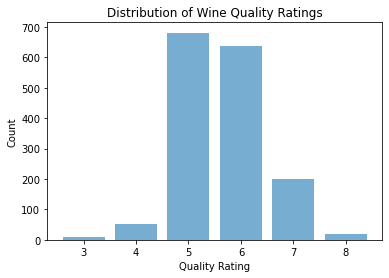

```python
#Map each quality rating to the amount present in the data
quality_counts = wine_data['quality'].value_counts()

import matplotlib.pyplot as plt  #Display graph to understand quality distribution
plt.bar(quality_counts.index, quality_counts.values,alpha=0.6) #X: possible ratings, Y: amount of each
plt.xlabel('Quality Rating')
plt.ylabel('Count')
plt.title('Distribution of Wine Quality Ratings')
plt.show()
```

As previously stated `describe` method's output, the bar graph also shows that 3 is the lowest quality rating present in the data, and 8 is the highest. The majority of wine samples seem to fall into the quality ratings 5 and 6. A note of interest is the sligt right skew in the quality distribution. We will now further explore the average characteristics of each quality rating.

```python
wine_data.groupby('quality').mean()
```

| quality | fixed acidity | volatile acidity | citric acid | residual sugar | chlorides | free sulfur dioxide | total sulfur dioxide | density | pH | sulphates | alcohol |
| --- | --- | --- | --- | --- | --- | --- | --- | --- | --- | --- | --- |
| 3 | 8.360000 | 0.884500 | 0.171000 | 2.635000 | 0.122500 | 11.000000 | 24.900000 | 0.997464 | 3.398000 | 0.570000 | 9.955000 |
| 4 | 7.779245 | 0.693962 | 0.174151 | 2.694340 | 0.090679 | 12.264151 | 36.245283 | 0.996542 | 3.381509 | 0.596415 | 10.265094 |
| 5 | 8.167254 | 0.577041 | 0.243686 | 2.528855 | 0.092736 | 16.983847 | 56.513950 | 0.997104 | 3.304949 | 0.620969 | 9.899706 |
| 6 | 8.347179 | 0.497484 | 0.273824 | 2.477194 | 0.084956 | 15.711599 | 40.869906 | 0.996615 | 3.318072 | 0.675329 | 10.629519 |
| 7 | 8.872362 | 0.403920 | 0.375176 | 2.720603 | 0.076588 | 14.045226 | 35.020101 | 0.996104 | 3.290754 | 0.741256 | 11.465913 |
| 8 | 8.566667 | 0.423333 | 0.391111 | 2.577778 | 0.068444 | 13.277778 | 33.444444 | 0.995212 | 3.267222 | 0.767778 | 12.094444 |

There appear to be trends in some of the attributes as quality increases. Displaying a correlation matrix will help in analyzing relations between properties and quality. The `seaborn` library will be particularly useful for this task.

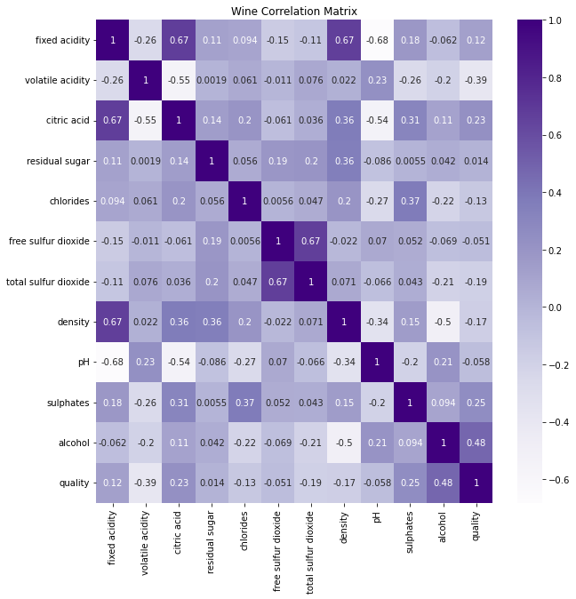

```python
import seaborn as sns
fig = plt.figure(figsize=(10, 10)) #Pass correlation matrix into heatmap constructor
ax = sns.heatmap(data=wine_data.corr(), annot=True,cmap='Purples')
plt.title('Wine Correlation Matrix')
plt.show()
```

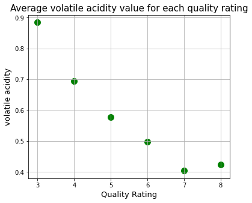

```python
# Plot the average value of a feature for each quality rating
def plot_quality_avg(feature):
    avg = wine_data.groupby('quality')[feature].mean() #Find each quality rating's avg feature value
    #Produce a labeled scatter plot for average feature value vs. quality rating
    plt.figure(figsize=(6, 5))
    plt.scatter(avg.index, avg.values, color='g', s=100)
    plt.title(f'Average {feature} value for each quality rating', fontsize=15)
    plt.xlabel('Quality Rating', fontsize=13)
    plt.ylabel(f'{feature}', fontsize=13)
    plt.grid()

plot_quality_avg('volatile acidity')
```

In the first plot, there is a clear downward trend; as the quality rating increases, the average volatile acidity decreases. It should be noted that quality 8 is not consistent with this trend, as its average volatile acidity rating is greater than that of quality 7. Nonetheless, the general trend indicates that volatile acidity is hihly correlated with quality rating.

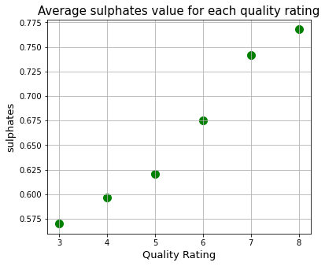

```python
plot_quality_avg('sulphates')
```

Our second plot depicts a strong positive correlation between the sulphates value and quality, showing that higher sulphate values are likely associated with higher quality wine.

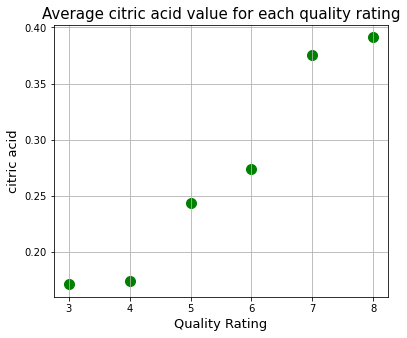

```python
plot_quality_avg('citric acid')
```

Another positive trend is shown between citric acid values and quality rating.

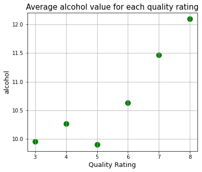

```python
plot_quality_avg('alcohol')
```

The fourth plot indicates that there is generally a trend between alcohol values and quality, however it should be noted that the rating 5 deviates from this trend.

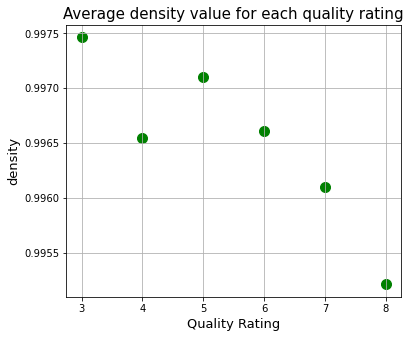

```python
plot_quality_avg('density')
```

Our final scatterplot suggests another general trend between density and quality. An important note is that quality rating 4 is not consistent with the trend.

We have developed an understanding of the wine dataset's structure, aswell as insight towards the distribution of quality ratings, general feature statistics, and knowledge of feature relations.

## Data Analysis - Diamonds

Similarly, the diamonds dataset comes in the form of a csv file titled `diamonds.csv`. The csv file contains entries which contain several attributes related to diamonds. First, the data will be extracted into a `Pandas` data frame to understand its formatting.

```python
diamond_data = pd.read_csv('datasets/diamonds.csv') # Extract diamond data
print(diamond_data.dtypes) # Check expected datatypes of every feature
print(f'Shape: {diamond_data.shape}') #Print the shape of the data frame
diamond_data.tail(5) # View last 5 elements of the data frame
```

```
Unnamed: 0      int64
carat         float64
cut            object
color          object
clarity        object
depth         float64
table         float64
price           int64
x             float64
y             float64
z             float64
dtype: object
Shape: (53940, 11)
```

|  | Unnamed: 0 | carat | cut | color | clarity | depth | table | price | x | y | z |
| --- | --- | --- | --- | --- | --- | --- | --- | --- | --- | --- | --- |
| 53935 | 53936 | 0.72 | Ideal | D | SI1 | 60.8 | 57.0 | 2757 | 5.75 | 5.76 | 3.50 |
| 53936 | 53937 | 0.72 | Good | D | SI1 | 63.1 | 55.0 | 2757 | 5.69 | 5.75 | 3.61 |
| 53937 | 53938 | 0.70 | Very Good | D | SI1 | 62.8 | 60.0 | 2757 | 5.66 | 5.68 | 3.56 |
| 53938 | 53939 | 0.86 | Premium | H | SI2 | 61.0 | 58.0 | 2757 | 6.15 | 6.12 | 3.74 |
| 53939 | 53940 | 0.75 | Ideal | D | SI2 | 62.2 | 55.0 | 2757 | 5.83 | 5.87 | 3.64 |

The dataset contains 53,940 rows each containing eleven attributes representing characteristics of diamonds. The data seems to be sorted based on the column titled 'Unamed: 0', where each entry is associated with an integer.

The price column consists of another integer, and the six attributes carat, depth, table, and dimensions (x, y, z) are of type float. There are also three objects cut, color, and clarity, appearing as strings in each entry.

To verify that there are no missing values, we will calculate the sum of missing entries.

```python
diamond_data.isnull().sum()
```

```
Unnamed: 0    0
carat         0
cut           0
color         0
clarity       0
depth         0
table         0
price         0
x             0
y             0
z             0
dtype: int64
```

The data contains no missing entries. As a necessary pre-processing step, we will now convert each of the strings to a categorical type.

```python
# Convert each string column to categorical type
diamond_data['cut'] = diamond_data['cut'].astype('category')
diamond_data['color'] = diamond_data['color'].astype('category')
diamond_data['clarity'] = diamond_data['clarity'].astype('category')
print(diamond_data.dtypes) #Verify
```

```
Unnamed: 0       int64
carat          float64
cut           category
color         category
clarity       category
depth          float64
table          float64
price            int64
x              float64
y              float64
z              float64
dtype: object
```

The describe method will now be utilized to quickly gather useful statistics regarding the numerical features present in the dataset.

```python
diamond_data.drop(columns=['Unnamed: 0']).describe() #Remove insignificant label from description
```

|  | carat | depth | table | price | x | y | z |
| --- | --- | --- | --- | --- | --- | --- | --- |
| count | 53940.000000 | 53940.000000 | 53940.000000 | 53940.000000 | 53940.000000 | 53940.000000 | 53940.000000 |
| mean | 0.797940 | 61.749405 | 57.457184 | 3932.799722 | 5.731157 | 5.734526 | 3.538734 |
| std | 0.474011 | 1.432621 | 2.234491 | 3989.439738 | 1.121761 | 1.142135 | 0.705699 |
| min | 0.200000 | 43.000000 | 43.000000 | 326.000000 | 0.000000 | 0.000000 | 0.000000 |
| 25% | 0.400000 | 61.000000 | 56.000000 | 950.000000 | 4.710000 | 4.720000 | 2.910000 |
| 50% | 0.700000 | 61.800000 | 57.000000 | 2401.000000 | 5.700000 | 5.710000 | 3.530000 |
| 75% | 1.040000 | 62.500000 | 59.000000 | 5324.250000 | 6.540000 | 6.540000 | 4.040000 |
| max | 5.010000 | 79.000000 | 95.000000 | 18823.000000 | 10.740000 | 58.900000 | 31.800000 |

The description shows some rather significant statistics. The minimum price value of a diamond in the dataset is 326, and the maximum price is 18,823. These facts, along with the high standard deviation value 3,989 indicate that the variance among price values is high. There is a clear correlation between the statistics in the x, y, and z columns. This is certainly due to the x, y, and z values representing physical dimensions (length, width, height) of the diamond.

Let's also explore the distribution of the categorical features present in the data such as cut, color, and clarity. The values of these features are categories which describe the quality and appearance of the diamonds.

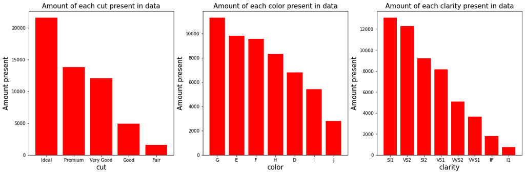

```python
#Display a bar graph showing the distribution of an attribute among the diamond data
def plot_attrib_distribution(attrib):
    attrib_counts = diamond_data[attrib].value_counts() #Map each class of the attrib to the amount present
    plt.bar(attrib_counts.index,attrib_counts,color='r') #Display and label bar graph
    plt.title(f'Amount of each {attrib} present in data',fontsize=15)
    plt.xlabel(f'{attrib}',fontsize=15)
    plt.ylabel('Amount present',fontsize=15)

plt.figure(figsize=(20,6))
plt.subplot(1,3,1)
plot_attrib_distribution('cut')
plt.subplot(1,3,2)
plot_attrib_distribution('color')
plt.subplot(1,3,3)
plot_attrib_distribution('clarity')
#Display a subplot showing the distribution of cut, color and clarity among the data
plt.show()
```

The cut distribution seems to follow a consistent trend of higher quality cuts being more common. The color distribution also shows that there is an imbalanced distribution of diamond color in the data. Similarly, the diamond clarity distribution reveals that SI1 and VS2 are by far the most frequent clarity values

By computing a correlation matrix, we can uncover relationships between the numerical features in the data. Most importantly, we will be able to identify attributes that may be useful in predicting the price of a diamond.

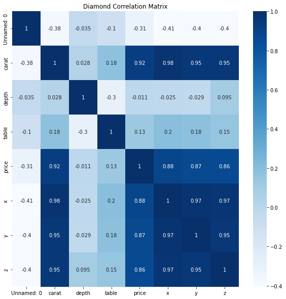

```python
fig = plt.figure(figsize=(10, 10)) #Pass correlation matrix into heatmap constructor
ax = sns.heatmap(data=diamond_data.corr(), annot=True,cmap='Blues')
plt.title('Diamond Correlation Matrix')
plt.show()
```

As expected, the matrix shows many significant correlations. The previously noted correlation between values x, y, and z is supported by the values in the matrix. Furthermore, there are four features which have an extremely high correlation with the price of a diamond. Among those features are carat, and the dimensions of the diamond x,y,z. An important note is that each of the four features are also heavily correlated with one another.

Using scatterplots, we will now visualize the high correlation between these variables and price.

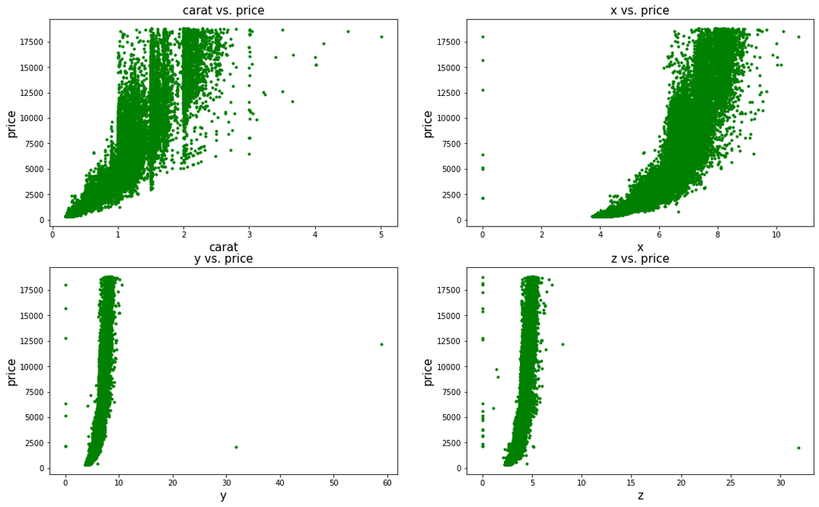

```python
#Plot the relationship betweeen a numerical attribute and price
def plot_price_correlation(attrib):
    plt.scatter(diamond_data[attrib], diamond_data['price'],marker='.',color='g')
    plt.xlabel(f'{attrib}',fontsize=15)
    plt.ylabel('price',fontsize=15)
    plt.title(f'{attrib} vs. price',fontsize=15)
plt.figure(figsize=(18,11))
plt.subplot(2,2,1)
plot_price_correlation('carat')
plt.subplot(2,2,2)
plot_price_correlation('x')
plt.subplot(2,2,3)
plot_price_correlation('y')
plt.subplot(2,2,4)
plot_price_correlation('z')
plt.show()
```

The plots depict the high correlations between these features and price, aswell as some outliers. The features y and z show a nearly identical exponential correlation with price. The x feature also shows an exponential correlation to a lesser degree. The carat value appears to have a more linear correlation, but the relation is less clear. Overall, as previously computed, the display confirms that each of these features have a strong positive correlation with price.

Finally, we will explore the relation between each of the categorical features and price.

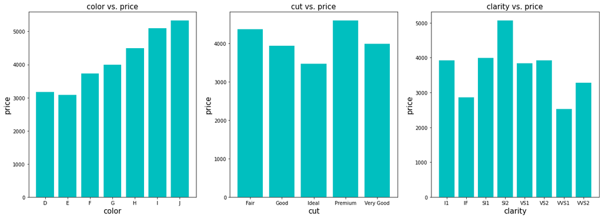

```python
#Bar plot a the average price of each class of a categorical value
def categorical_price_correlation(attrib):
    avg_prices = diamond_data.groupby(attrib)['price'].mean()
    plt.bar(avg_prices.index, avg_prices,color='c')
    plt.xlabel(f'{attrib}',fontsize=15)
    plt.ylabel('price',fontsize=15)
    plt.title(f'{attrib} vs. price',fontsize=15)
plt.figure(figsize=(21,7))
plt.subplot(1,3,1)
categorical_price_correlation('color')
plt.subplot(1,3,2)
categorical_price_correlation('cut')
plt.subplot(1,3,3)
categorical_price_correlation('clarity')
plt.show()
```

The bar plots show that the categorical features have a considerable effect on price. Among each of the categorical features, several classes have a greater average price than other classes. The color class 'j' is just one example of this, having a greater average price than each other color. Along with color, clarity seems to have a large effect on price. Cut does have some effect on price, but to a much lesser degree.

Our analysis has revealed several significant findings. We were able to determine that the price of diamonds in the dataset is highly variant. Analysis of correlations between features and price highlighted several features including carat, x, y, and z, each of which having an extremely high correlation to price. This provides valuable insight towards developing a model to predict the price of a diamond.

## References

[1] https://pandas.pydata.org/docs/reference/api/pandas.Series.cat.categories.html

[2] https://pandas.pydata.org/docs/reference/api/pandas.Series.value_counts.html

[3] https://pandas.pydata.org/docs/reference/api/pandas.DataFrame.groupby.html

[4] https://pandas.pydata.org/docs/reference/api/pandas.DataFrame.corr.html

[5] https://seaborn.pydata.org/generated/seaborn.heatmap.html